# Decison tree prediction model for the classification of the the species using length,width of sepal and petal

1 September 2018

## Project objective

The aim of the project is to predict the species using the length and width of Sepal and Width.Decision tree will be used for the prediction.As a part of the project a web application will be developed to predict the species by providing the required details.

Requisites of the project:  
1. iris dataset(available in R)  
2. shiny(web framework by Rstudio)  
3. caret package of R  
4. rattle package of R

## Data

The dataset being used to train the model is iris dataset.

```
    Sepal.Length Sepal.Width Petal.Length Petal.Width Species
  1          5.1         3.5          1.4         0.2  setosa
  2          4.9         3.0          1.4         0.2  setosa
  3          4.7         3.2          1.3         0.2  setosa
  4          4.6         3.1          1.5         0.2  setosa
  5          5.0         3.6          1.4         0.2  setosa
  6          5.4         3.9          1.7         0.4  setosa
```

We can see that that the iris dataset is a good choice to develop a prediction model for the species.

## Decison tree

The following decision tree will be used for prediction:

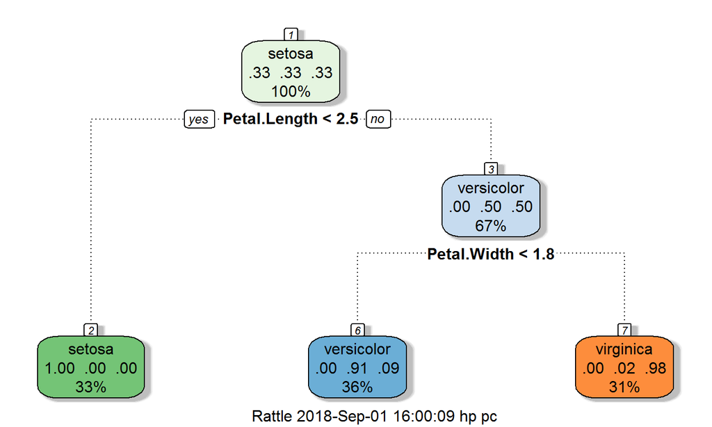

## Functionality of the application

The application will provide an interface to enter the dimensions of petal and sepal.These details will be used to predict the species of the flower.

The following details will be needed:

## Link to the project

The code for the application can be found [Here](https://github.com/shubhanshumohan/shiny_app)